# Predicting Weight-Lifting Exercise Quality from Wearable Sensors

Zaosh

2026-11-04

## Summary

Six participants performed dumbbell biceps curls in five ways (`classe`): exactly to specification (**A**) and with four common mistakes (**B** throwing elbows forward, **C** lifting halfway, **D** lowering halfway, **E** throwing hips forward). Sensors on the belt, forearm, arm and dumbbell recorded motion. I build a classifier of `classe` from these sensor readings, using a random forest tuned with 5-fold cross-validation and checked against a held-out validation set. Data: Velloso, Bulling, Gellersen, Ugulino and Fuks, *Qualitative Activity Recognition of Weight Lifting Exercises* (HAR, PUC-Rio).

## Data and cleaning

```r
train_raw <- read.csv("data/pml-training.csv", na.strings = c("NA", "", "#DIV/0!"))
test_raw  <- read.csv("data/pml-testing.csv",  na.strings = c("NA", "", "#DIV/0!"))
dim(train_raw)
```

```
## [1] 19622   160
```

Many columns are summary statistics (kurtosis, skewness, max, min, amplitude, avg, var, stddev) populated only on the rows where `new_window == "yes"`; in the 20 test cases they are entirely `NA`. A model cannot use them at prediction time, so I drop every column that is more than 90% missing in training. I also drop row index, user name, timestamps and window identifiers: they identify *when/who*, not *how*, and would let a model “cheat” by position in the recording session rather than learn movement, which would not generalise to new data.

```r
na_frac <- colMeans(is.na(train_raw))
keep <- names(na_frac)[na_frac < 0.9]
drop_id <- c("X","user_name","raw_timestamp_part_1","raw_timestamp_part_2",
             "cvtd_timestamp","new_window","num_window")
keep <- setdiff(keep, drop_id)
train <- train_raw[, keep]
train$classe <- factor(train$classe)
test  <- test_raw[, intersect(setdiff(keep, "classe"), names(test_raw))]
ncol(train) - 1   # predictors retained
```

```
## [1] 52
```

```r
all(setdiff(names(train), "classe") %in% names(test))
```

```
## [1] TRUE
```

Remaining near-zero-variance predictors: 0.

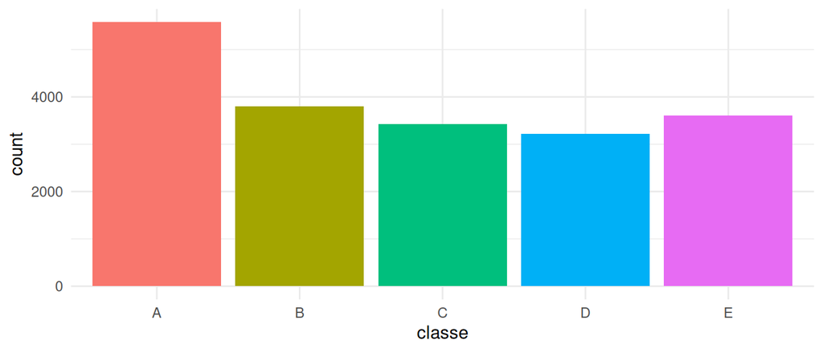

Figure 1: Class balance in the training data.

```r
ggplot(train, aes(classe, fill = classe)) + geom_bar(show.legend = FALSE) +
  labs(x = "classe", y = "count") + theme_minimal()
```

Classes are reasonably balanced (A is the most frequent), so plain accuracy is a sensible metric.

## Modelling and cross-validation

I hold out 25% of the training data as a **validation set** that is never touched during tuning. On the remaining 75% I use **5-fold cross-validation** to compare models and tune hyperparameters. Random forests need no scaling, handle correlated and non-linear predictors, and are known to perform very well on this dataset. I compare against gradient boosting (GBM) and a single CART tree as a baseline.

```r
idx <- createDataPartition(train$classe, p = 0.75, list = FALSE)
trn <- train[idx, ]; val <- train[-idx, ]
ctrl <- trainControl(method = "cv", number = 5)
```

```r
fit_rf   <- train(classe ~ ., data = trn, method = "rf", trControl = ctrl,
                  tuneGrid = data.frame(mtry = c(2, 7, 14, 27)), ntree = 200)
fit_gbm  <- train(classe ~ ., data = trn, method = "gbm", trControl = ctrl, verbose = FALSE,
                  tuneGrid = expand.grid(n.trees = 150, interaction.depth = 3,
                                         shrinkage = 0.1, n.minobsinnode = 10))
fit_tree <- train(classe ~ ., data = trn, method = "rpart", trControl = ctrl)
cv_tab <- data.frame(
  model = c("Random forest", "GBM", "CART tree"),
  cv_accuracy = c(max(fit_rf$results$Accuracy), max(fit_gbm$results$Accuracy),
                  max(fit_tree$results$Accuracy)))
cv_tab$cv_error <- 1 - cv_tab$cv_accuracy
cv_tab
```

```
##           model cv_accuracy    cv_error
## 1 Random forest   0.9935453 0.006454658
## 2           GBM   0.9612727 0.038727331
## 3     CART tree   0.5067276 0.493272379
```

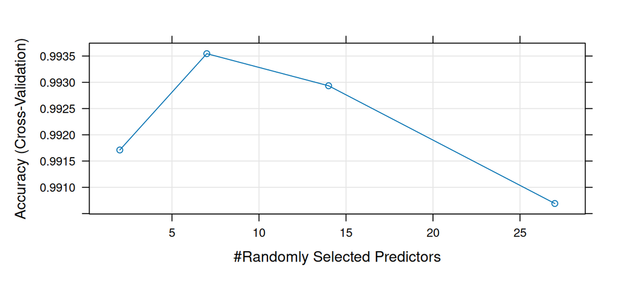

Figure 2: Cross-validated accuracy of the random forest versus mtry.

```r
plot(fit_rf, main = "")
```

The random forest is clearly best (the single tree is far weaker), so I select it. Best `mtry`: 7.

## Expected out-of-sample error

Cross-validation gives an estimate from folds of the training portion; the validation set gives an independent check, since it played no role in model selection.

```r
cm <- confusionMatrix(predict(fit_rf, val), val$classe)
cm$table
```

```
##           Reference
## Prediction    A    B    C    D    E
##          A 1395    7    0    0    0
##          B    0  941    3    0    0
##          C    0    1  849    6    2
##          D    0    0    3  797    1
##          E    0    0    0    1  898
```

```r
cm$overall[c("Accuracy", "AccuracyLower", "AccuracyUpper")]
```

```
##      Accuracy AccuracyLower AccuracyUpper
##     0.9951060     0.9927269     0.9968619
```

Validation accuracy is **99.51%**, so the estimated out-of-sample error is about **0.49%** (CV estimate: 0.65%).

**Caveat.** The random split mixes rows from the same participants and repetitions, so both estimates are likely optimistic relative to a *new person*. A leave-one-participant-out check (below) quantifies this.

```r
users <- train_raw$user_name[idx_all <- seq_len(nrow(train))]
lopo <- sapply(levels(users <- factor(train_raw$user_name)), function(u) {
  tr <- train[users != u, ]; te <- train[users == u, ]
  m <- randomForest(classe ~ ., data = tr, ntree = 100, mtry = fit_rf$bestTune$mtry)
  mean(predict(m, te) == te$classe)
})
round(lopo, 3); mean(lopo)
```

```
##   adelmo carlitos  charles   eurico   jeremy    pedro
##    0.183    0.496    0.569    0.191    0.501    0.321
```

```
## [1] 0.3769518
```

Accuracy on an unseen participant is lower (mean 37.7%), so the realistic error for brand-new users is higher than the random-split figure. The 20 quiz cases are drawn from the same six participants, so the random-split estimate is the relevant one for them.

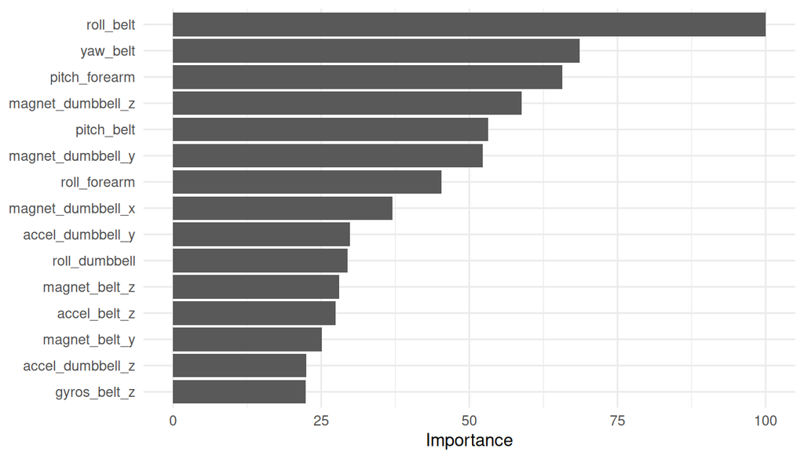

Figure 3: Top 15 most important predictors.

```r
imp <- varImp(fit_rf)$importance
imp$var <- rownames(imp)
imp <- head(imp[order(-imp$Overall), ], 15)
ggplot(imp, aes(reorder(var, Overall), Overall)) + geom_col() + coord_flip() +
  labs(x = NULL, y = "Importance") + theme_minimal()
```

## Final model and test predictions

For the final model I refit the chosen random forest on **all** labelled data (training + validation) with the tuned `mtry`, then predict the 20 test cases.

```r
final <- randomForest(classe ~ ., data = train, ntree = 500, mtry = fit_rf$bestTune$mtry)
pred <- predict(final, test[, setdiff(names(train), "classe")])
data.frame(problem_id = test_raw$problem_id, prediction = pred)
```

```
##    problem_id prediction
## 1           1          B
## 2           2          A
## 3           3          B
## 4           4          A
## 5           5          A
## 6           6          E
## 7           7          D
## 8           8          B
## 9           9          A
## 10         10          A
## 11         11          B
## 12         12          C
## 13         13          B
## 14         14          A
## 15         15          E
## 16         16          E
## 17         17          A
## 18         18          B
## 19         19          B
## 20         20          B
```

```r
writeLines(as.character(pred), "predictions.txt")
```

## Choices in brief

- Dropped sparse summary columns and identifiers to avoid leakage and unusable features.
- Random forest chosen by 5-fold CV over GBM and CART; validation set kept untouched for an honest error estimate.
- Final model refit on all labelled data to use every example.